# Improving Classification with Neural Networks

### Using the Keras Package and TensorFlow

By Austin Goodrich

#### For this demonstration I followed the guide found [here](https://realpython.com/python-keras-text-classification/)

It is important to note that this walkthrough is conducted in Python 3.7.4 where the linked guide is for a version of Python that the author failed to mention. There are also several errors within the original source.

# Outline

### 1. Saving and Loading .txt files

### 2. Building Basic Model

### 3. Out of Box Neural Net Model with Keras with TensorFlow

### 4. Improvements to Neural Net through Word Embedding

### 5. Convolutional Neural Networks (CNN)

### 6. Hyperparameters Optimization

# Saving and Loading .txt Files

#### Saving the data

##### Create a folder

Create a folder somewhere convenient. On my external hardrive I have a folder called python and inside that folder I created a folder called data.

##### Download the data

This walkthrough uses three datasets stored in sentiment_labelled_sentences.zip that can be downloaded [Here](https://archive.ics.uci.edu/ml/machine-learning-databases/00331/)

Note: My computer kept trying to download the zip file as a pdf, make sure you right click the link and save link as .zip.

##### Extract the files

I extracted the files and copied them into the folder created in step 1. I stored the files in a folder called sentiment_analysis in the created data folder.

##### Now an example absolute path for one of the txt files is

E:/python/data/sentiment_analysis/yelp_labelled.txt

E: for the external hard drive. It could be C: if you saved the files on your computer.

## Loading the data into Python

###### - We can load the data into python using the absolute paths.

###### - We can then reference locations within our list using df.iloc[]

###### - Finally we can see that the first element of our list is a yelp review that says "wow... Loved this place." and it is coded 1 which means positive (0 means negative).

```python
import pandas as pd

filepath_dict = {'yelp': 'E:/python/data/sentiment_analysis/yelp_labelled.txt',
                 'amazon': 'E:/python/data/sentiment_analysis/amazon_cells_labelled.txt',
                 'imdb': 'E:/python/data/sentiment_analysis/imdb_labelled.txt'}

df_list = []
for source, filepath in filepath_dict.items():
    df = pd.read_csv(filepath, names=['sentence', 'label'], sep='\t')
    df['source'] = source  # Add another column filled with the source name
    df_list.append(df)

df = pd.concat(df_list)
print(df.iloc[0])
```

```
sentence    Wow... Loved this place.
label                              1
source                          yelp
Name: 0, dtype: object
```

# Fitting a Basic Logistic Regression Model

##### Here is an example of fitting a logistic regression model using only the yelp reviews.

###### There are parts of this code that might seem familiar.

###### 1. x_train and x_test refer to our training and test set, we can see that they were split using train_test_split with 25 percent of the data in the test set.

##### 2. random.state = 1000 is similar to setting a seed.

##### 3. Remember our goal is classification, we want to predict whether a review is a 0 (negative) or a 1 (positive).

##### 4. We built our logistic regression model on the training data and printed out the accuracy onto the test data. 79.6% accuracy, is that good? I don't know.

```python
from sklearn.model_selection import train_test_split
df_yelp = df[df['source'] == 'yelp']
sentences = df_yelp['sentence'].values
y = df_yelp['label'].values

sentences_train, sentences_test, y_train, y_test = train_test_split(sentences, y, test_size=0.25, random_state=1000)

from sklearn.feature_extraction.text import CountVectorizer

vectorizer = CountVectorizer()
vectorizer.fit(sentences_train)

X_train = vectorizer.transform(sentences_train) # We should be familiar
X_test  = vectorizer.transform(sentences_test)  # with training and testing

from sklearn.linear_model import LogisticRegression

classifier = LogisticRegression()
classifier.fit(X_train, y_train)
score = classifier.score(X_test, y_test)

print("Accuracy:", score)
```

```
Accuracy: 0.796
```

#### Lets do the same thing but include Amazon and IMDB reviews.

##### Notice that df[df['source'] == source] is similar to dplyr %>% filter(variable.a %in% thing)

```python
for source in df['source'].unique():
    df_source = df[df['source'] == source]
    sentences = df_source['sentence'].values
    y = df_source['label'].values

    sentences_train, sentences_test, y_train, y_test = train_test_split(
        sentences, y, test_size=0.25, random_state=1000)

    vectorizer = CountVectorizer()
    vectorizer.fit(sentences_train)
    X_train = vectorizer.transform(sentences_train)
    X_test  = vectorizer.transform(sentences_test)

    classifier = LogisticRegression()
    classifier.fit(X_train, y_train)
    score = classifier.score(X_test, y_test)
    print('Accuracy for {} data: {:.4f}'.format(source, score))
```

```
Accuracy for yelp data: 0.7960
Accuracy for amazon data: 0.7960
Accuracy for imdb data: 0.7487
```

# Keras using TensorFlow

##### Make sure to first install keras and tensorflow

### Setting up Neural Network

#### Neural Networks are like ogres and onions, they have layers

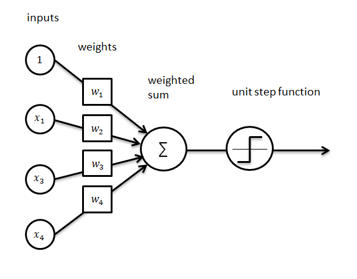

##### We don't have to fully understand what is going on, but the basics are

##### 1. assign random weights to our nodes

##### 2. Train the model with a method called backpropagation, which is a scary way to say that we are going to use optimizations to minimize error towards the desired output.

##### In other words we are going to play a game of warmer colder.

### Initializing the model

##### - relu stands for Rectified Linear Unit and is just specifying how the model layers are set up, similarily with sigmoid.

##### - loss specifies how error is determined, in this case, error is determined by binary crossentropy. This is a good choice since our response is 0,1

##### - optimizer is how our model is being optimized, adam is the specified optimization function.

#### We can see that there are 25,071 parameters (we probably don't want to do these calculations by hand)

```python
from keras.models import Sequential
from keras import layers

input_dim = X_train.shape[1]  # Number of features

model = Sequential()
model.add(layers.Dense(10, input_dim=input_dim, activation='relu'))
model.add(layers.Dense(1, activation='sigmoid'))


model.compile(loss='binary_crossentropy',
              optimizer='adam',
              metrics=['accuracy'])


model.summary()
```

```
Model: "sequential_2"
_________________________________________________________________
Layer (type)                 Output Shape              Param #
=================================================================
dense_3 (Dense)              (None, 10)                25060
_________________________________________________________________
dense_4 (Dense)              (None, 1)                 11
=================================================================
Total params: 25,071
Trainable params: 25,071
Non-trainable params: 0
_________________________________________________________________
```

### Lets run the model

#### - epochs are the number of times the model will iterate

#### - batch size is a parameter that changes the number of computations per iteration and the rule of thumb is that you use fewer when you have fewer data points

##### - We can see that the training set has 100% accuracy, but it is overfitting onto the test set.

```python
history = model.fit(X_train, y_train,
                    epochs=100,
                    verbose=False,
                    validation_data=(X_test, y_test),
                    batch_size=10)

loss, accuracy = model.evaluate(X_train, y_train, verbose=False)
print("Training Accuracy: {:.4f}".format(accuracy))
loss, accuracy = model.evaluate(X_test, y_test, verbose=False)
print("Testing Accuracy:  {:.4f}".format(accuracy))
```

```
Training Accuracy: 1.0000
Testing Accuracy:  0.7968
```

### We can visually assess model accuracy throughout the training process through plots

##### We can see that at around 20 the model starts overfitting onto the training, which results in a decrease in accuracy onto the test set.

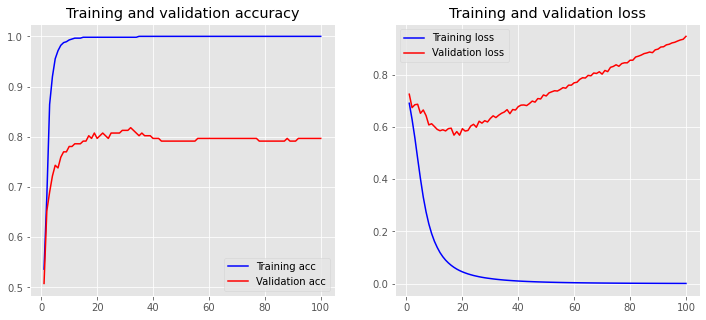

```python
import matplotlib.pyplot as plt
plt.style.use('ggplot')

def plot_history(history):
    acc = history.history['accuracy']
    val_acc = history.history['val_accuracy']
    loss = history.history['loss']
    val_loss = history.history['val_loss']
    x = range(1, len(acc) + 1)

    plt.figure(figsize=(12, 5))
    plt.subplot(1, 2, 1)
    plt.plot(x, acc, 'b', label='Training acc')
    plt.plot(x, val_acc, 'r', label='Validation acc')
    plt.title('Training and validation accuracy')
    plt.legend()
    plt.subplot(1, 2, 2)
    plt.plot(x, loss, 'b', label='Training loss')
    plt.plot(x, val_loss, 'r', label='Validation loss')
    plt.title('Training and validation loss')
    plt.legend()

plot_history(history)
```

# Word Embedding

##### We have just ran an out-of-box Neural Net and achieved similar accuracy to the logistic regression model. Can we improve our accuracy even further?

### How do we get word embeddings?

#### 1. Train word embeddings using a neural network

#### 2. Use pretrained word embeddings

##### In order to use word embeddings we have to convert our data.

##### This conversion requires tokinization. This takes our text and convers it into integers. These integers are keys that relate to a dictionary.

##### In order for this process to work our text sequences have to be the same length. the pad_sequence function below adds 0's to fill in the missing spaces up to a certain length specified by maxlen.

```python
from keras.preprocessing.text import Tokenizer

tokenizer = Tokenizer(num_words=5000)
tokenizer.fit_on_texts(sentences_train)

X_train = tokenizer.texts_to_sequences(sentences_train)
X_test = tokenizer.texts_to_sequences(sentences_test)

vocab_size = len(tokenizer.word_index) + 1


from keras.preprocessing.sequence import pad_sequences

maxlen = 100

X_train = pad_sequences(X_train, padding='post', maxlen=maxlen)
X_test = pad_sequences(X_test, padding='post', maxlen=maxlen)
```

##### Now that we've tokenized and padded our training and test set we can embed our data

##### Now we have 129,271 trainable parameters (wow)

#### Lets run the new model

```python
from keras.models import Sequential
from keras import layers

embedding_dim = 50

model = Sequential()
model.add(layers.Embedding(input_dim=vocab_size,
                           output_dim=embedding_dim,
                           input_length=maxlen))
model.add(layers.GlobalMaxPool1D())
model.add(layers.Dense(10, activation='relu'))
model.add(layers.Dense(1, activation='sigmoid'))
model.compile(optimizer='adam',
              loss='binary_crossentropy',
              metrics=['accuracy'])
model.summary()
```

```
Model: "sequential_5"
_________________________________________________________________
Layer (type)                 Output Shape              Param #
=================================================================
embedding_3 (Embedding)      (None, 100, 50)           128750
_________________________________________________________________
global_max_pooling1d_1 (Glob (None, 50)                0
_________________________________________________________________
dense_9 (Dense)              (None, 10)                510
_________________________________________________________________
dense_10 (Dense)             (None, 1)                 11
=================================================================
Total params: 129,271
Trainable params: 129,271
Non-trainable params: 0
_________________________________________________________________
```

#### It appears that the added features did not help our accuracy

```
Training Accuracy: 1.0000
Testing Accuracy:  0.7807
```

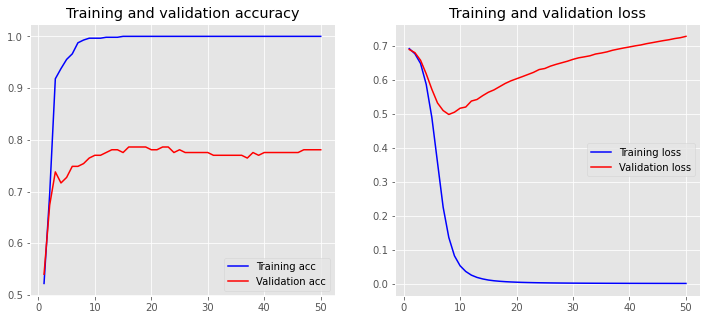

```python
history = model.fit(X_train, y_train,
                    epochs=50,
                    verbose=False,
                    validation_data=(X_test, y_test),
                    batch_size=10)
loss, accuracy = model.evaluate(X_train, y_train, verbose=False)
print("Training Accuracy: {:.4f}".format(accuracy))
loss, accuracy = model.evaluate(X_test, y_test, verbose=False)
print("Testing Accuracy:  {:.4f}".format(accuracy))
plot_history(history)
```

### Using Pretrained Word Embeddings

#### Downloading pretrained word embeddings from stanford

[Glove 6B Pretrained Word Embeddings download](http://nlp.stanford.edu/data/glove.6B.zip)

[Link to main website](https://nlp.stanford.edu/projects/glove/)

##### If you are following along, you will need to download the word embeddings and then put them into your data folder. The files should be in .txt form after you extract the download.

### Running New Model with Word Embeddings from Glove

```
Model: "sequential_6"
_________________________________________________________________
Layer (type)                 Output Shape              Param #
=================================================================
embedding_4 (Embedding)      (None, 100, 50)           128750
_________________________________________________________________
global_max_pooling1d_2 (Glob (None, 50)                0
_________________________________________________________________
dense_11 (Dense)             (None, 10)                510
_________________________________________________________________
dense_12 (Dense)             (None, 1)                 11
=================================================================
Total params: 129,271
Trainable params: 521
Non-trainable params: 128,750
_________________________________________________________________
Training Accuracy: 0.7807
Testing Accuracy:  0.7326
```

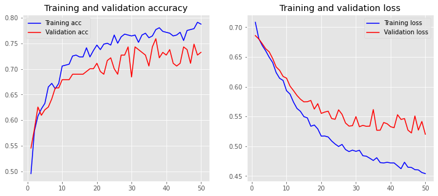

```python
import numpy as np

def create_embedding_matrix(filepath, word_index, embedding_dim):
    vocab_size = len(word_index) + 1  # Adding again 1 because of reserved 0 index
    embedding_matrix = np.zeros((vocab_size, embedding_dim))

    with open(filepath, encoding="utf8") as f:
        for line in f:
            word, *vector = line.split()
            if word in word_index:
                idx = word_index[word]
                embedding_matrix[idx] = np.array(
                    vector, dtype=np.float32)[:embedding_dim]

    return embedding_matrix

embedding_dim = 50
embedding_matrix = create_embedding_matrix('E:/python/data/glove.6B.50d.txt',
     tokenizer.word_index, embedding_dim)


nonzero_elements = np.count_nonzero(np.count_nonzero(embedding_matrix, axis=1))
nonzero_elements / vocab_size


model = Sequential()
model.add(layers.Embedding(vocab_size, embedding_dim,
                           weights=[embedding_matrix],
                           input_length=maxlen,
                           trainable=False))
model.add(layers.GlobalMaxPool1D())
model.add(layers.Dense(10, activation='relu'))
model.add(layers.Dense(1, activation='sigmoid'))
model.compile(optimizer='adam',
              loss='binary_crossentropy',
              metrics=['accuracy'])
model.summary()


history = model.fit(X_train, y_train,
                    epochs=50,
                    verbose=False,
                    validation_data=(X_test, y_test),
                    batch_size=10)
loss, accuracy = model.evaluate(X_train, y_train, verbose=False)
print("Training Accuracy: {:.4f}".format(accuracy))
loss, accuracy = model.evaluate(X_test, y_test, verbose=False)
print("Testing Accuracy:  {:.4f}".format(accuracy))
plot_history(history)
```

### Once again the accuracy doesn't seem to be improving with the word embedding methods. This is a learning process though, and if we found the best model from the start, where would the fun be?

##### Lets allow for our word embeddings to be trained during the process

```
Model: "sequential_7"
_________________________________________________________________
Layer (type)                 Output Shape              Param #
=================================================================
embedding_5 (Embedding)      (None, 100, 50)           128750
_________________________________________________________________
global_max_pooling1d_3 (Glob (None, 50)                0
_________________________________________________________________
dense_13 (Dense)             (None, 10)                510
_________________________________________________________________
dense_14 (Dense)             (None, 1)                 11
=================================================================
Total params: 129,271
Trainable params: 129,271
Non-trainable params: 0
_________________________________________________________________
Training Accuracy: 1.0000
Testing Accuracy:  0.7647
```

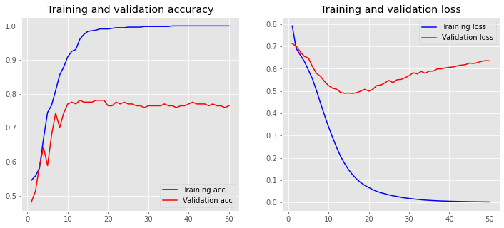

```python
model = Sequential()
model.add(layers.Embedding(vocab_size, embedding_dim,
                           weights=[embedding_matrix],
                           input_length=maxlen,
                           trainable=True))
model.add(layers.GlobalMaxPool1D())
model.add(layers.Dense(10, activation='relu'))
model.add(layers.Dense(1, activation='sigmoid'))
model.compile(optimizer='adam',
              loss='binary_crossentropy',
              metrics=['accuracy'])
model.summary()


history = model.fit(X_train, y_train,
                    epochs=50,
                    verbose=False,
                    validation_data=(X_test, y_test),
                    batch_size=10)
loss, accuracy = model.evaluate(X_train, y_train, verbose=False)
print("Training Accuracy: {:.4f}".format(accuracy))
loss, accuracy = model.evaluate(X_test, y_test, verbose=False)
print("Testing Accuracy:  {:.4f}".format(accuracy))
plot_history(history)
```

##### This is a little better, but we are still worse off then at the start.

### Lets try a Convolutional Neural Network (CNN)

#### this is specified by the .conv1D argument

##### This type of neural network has been the hot model for image classification

```
Model: "sequential_8"
_________________________________________________________________
Layer (type)                 Output Shape              Param #
=================================================================
embedding_6 (Embedding)      (None, 100, 100)          257500
_________________________________________________________________
conv1d_1 (Conv1D)            (None, 96, 128)           64128
_________________________________________________________________
global_max_pooling1d_4 (Glob (None, 128)               0
_________________________________________________________________
dense_15 (Dense)             (None, 10)                1290
_________________________________________________________________
dense_16 (Dense)             (None, 1)                 11
=================================================================
Total params: 322,929
Trainable params: 322,929
Non-trainable params: 0
_________________________________________________________________
```

```
Training Accuracy: 1.0000
Testing Accuracy:  0.7861
```

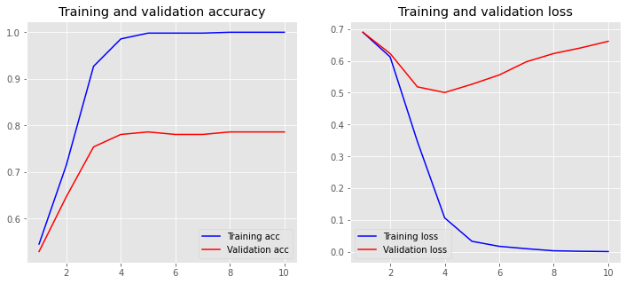

```python
embedding_dim = 100

model = Sequential()
model.add(layers.Embedding(vocab_size, embedding_dim, input_length=maxlen))
model.add(layers.Conv1D(128, 5, activation='relu'))
model.add(layers.GlobalMaxPooling1D())
model.add(layers.Dense(10, activation='relu'))
model.add(layers.Dense(1, activation='sigmoid'))
model.compile(optimizer='adam',
              loss='binary_crossentropy',
              metrics=['accuracy'])
model.summary()

history = model.fit(X_train, y_train,
                    epochs=10,
                    verbose=False,
                    validation_data=(X_test, y_test),
                    batch_size=10)
loss, accuracy = model.evaluate(X_train, y_train, verbose=False)
print("Training Accuracy: {:.4f}".format(accuracy))
loss, accuracy = model.evaluate(X_test, y_test, verbose=False)
print("Testing Accuracy:  {:.4f}".format(accuracy))
plot_history(history)
```

#### We have made it almost back to where we started! That's not all that exciting, but you can see how these models are like messing around with TV antennas (or finding cell service in the middle of nowhere for a more modern example)

# Hyperparameter Optimization

##### Make sure to specify the absolute path when saving the output to a .txt file.

```python
def create_model(num_filters, kernel_size, vocab_size, embedding_dim, maxlen):
    model = Sequential()
    model.add(layers.Embedding(vocab_size, embedding_dim, input_length=maxlen))
    model.add(layers.Conv1D(num_filters, kernel_size, activation='relu'))
    model.add(layers.GlobalMaxPooling1D())
    model.add(layers.Dense(10, activation='relu'))
    model.add(layers.Dense(1, activation='sigmoid'))
    model.compile(optimizer='adam',
                  loss='binary_crossentropy',
                  metrics=['accuracy'])
    return model

param_grid = dict(num_filters=[32, 64, 128],
                  kernel_size=[3, 5, 7],
                  vocab_size=[5000],
                  embedding_dim=[50],
                  maxlen=[100])


from keras.wrappers.scikit_learn import KerasClassifier
from sklearn.model_selection import RandomizedSearchCV

# Main settings
epochs = 20
embedding_dim = 50
maxlen = 100
output_file = 'E:\python\data/output.txt'

# Run grid search for each source (yelp, amazon, imdb)
for source, frame in df.groupby('source'):
    print('Running grid search for data set :', source)
    sentences = df['sentence'].values
    y = df['label'].values

    # Train-test split
    sentences_train, sentences_test, y_train, y_test = train_test_split(
        sentences, y, test_size=0.25, random_state=1000)

    # Tokenize words
    tokenizer = Tokenizer(num_words=5000)
    tokenizer.fit_on_texts(sentences_train)
    X_train = tokenizer.texts_to_sequences(sentences_train)
    X_test = tokenizer.texts_to_sequences(sentences_test)

    # Adding 1 because of reserved 0 index
    vocab_size = len(tokenizer.word_index) + 1

    # Pad sequences with zeros
    X_train = pad_sequences(X_train, padding='post', maxlen=maxlen)
    X_test = pad_sequences(X_test, padding='post', maxlen=maxlen)

    # Parameter grid for grid search
    param_grid = dict(num_filters=[32, 64, 128],
                      kernel_size=[3, 5, 7],
                      vocab_size=[vocab_size],
                      embedding_dim=[embedding_dim],
                      maxlen=[maxlen])
    model = KerasClassifier(build_fn=create_model,
                            epochs=epochs, batch_size=10,
                            verbose=False)
    grid = RandomizedSearchCV(estimator=model, param_distributions=param_grid,
                              cv=4, verbose=1, n_iter=5)
    grid_result = grid.fit(X_train, y_train)

    # Evaluate testing set
    test_accuracy = grid.score(X_test, y_test)

    # Save and evaluate results
    prompt = input(f'finished {source}; write to file and proceed? [y/n]')
    if prompt.lower() not in {'y', 'true', 'yes'}:
        break
    with open(output_file, 'a') as f:
        s = ('Running {} data set\nBest Accuracy : '
             '{:.4f}\n{}\nTest Accuracy : {:.4f}\n\n')
        output_string = s.format(
            source,
            grid_result.best_score_,
            grid_result.best_params_,
            test_accuracy)
        print(output_string)
        f.write(output_string)
```

##### Here is the output when run on the three datasets!

Running amazon data set Best Accuracy : 0.8205 {'vocab_size': 4603, 'num_filters': 32, 'maxlen': 100, 'kernel_size': 5, 'embedding_dim': 50} Test Accuracy : 0.8268

Running imdb data set Best Accuracy : 0.8142 {'vocab_size': 4603, 'num_filters': 128, 'maxlen': 100, 'kernel_size': 3, 'embedding_dim': 50} Test Accuracy : 0.8341

Running yelp data set Best Accuracy : 0.8161 {'vocab_size': 4603, 'num_filters': 128, 'maxlen': 100, 'kernel_size': 5, 'embedding_dim': 50} Test Accuracy : 0.8224

#### We did it, we broke 80% accuracy!

##### There you have it, some model building with neural networks using the Keras package and TensorFlow

##### Once again most of this code is not mine, I borrowed the code and story progression from [here](https://realpython.com/python-keras-text-classification/)

##### The walkthrough goes through the "behind the scenes" in more detail

##### This was typed up in Jupyter Notebook, which is awesome.